# Divvy Bike Case Study

Andrew Sundberg

2023-11-01

## Cyclistic Exercise 1st Quarter of 2020 Analysis

###### This analysis is for case study 1 from the Google Data Analytics Certificate (Cyclistic). It’s originally based on the case study “‘Sophisticated, Clear, and Polished’: Divvy and Data Visualization” written by Kevin Hartman (found here: https://artscience.blog/home/divvy-dataviz-case-study). We will be using the Divvy dataset for the case study. The purpose of this script is to consolidate downloaded Divvy data into a single dataframe and then conduct simple analysis to help answer the key question: “In what ways do members and casual riders use Divvy bikes differently?”

### Install required packages

```r
library(tidyverse)  #helps wrangle data
```

```r
library(lubridate)  #helps wrangle date attributes
library(ggplot2)  #helps visualize data
getwd() #displays your working directory
```

```
## [1] "C:/Users/ajsun/OneDrive/Documents/Divvy_Trips_2020_Q1"
```

```r
setwd("C:/Users/ajsun/OneDrive/Documents/Divvy_Trips_2020_Q1")
```

```r
q1_2020 <- read_csv("Divvy_Trips_2020_Q1.csv")
colnames(q1_2020)
```

```
##  [1] "ride_id"            "rideable_type"      "started_at"
##  [4] "ended_at"           "start_station_name" "start_station_id"
##  [7] "end_station_name"   "end_station_id"     "start_lat"
## [10] "start_lng"          "end_lat"            "end_lng"
## [13] "member_casual"
```

```r
str(q1_2020)
```

```
## spc_tbl_ [426,887 × 13] (S3: spec_tbl_df/tbl_df/tbl/data.frame)
##  $ ride_id           : chr [1:426887] "EACB19130B0CDA4A" "8FED874C809DC021" "789F3C21E472CA96" "C9A388DAC6ABF313" ...
##  $ rideable_type     : chr [1:426887] "docked_bike" "docked_bike" "docked_bike" "docked_bike" ...
##  $ started_at        : POSIXct[1:426887], format: "2020-01-21 20:06:59" "2020-01-30 14:22:39" ...
##  $ ended_at          : POSIXct[1:426887], format: "2020-01-21 20:14:30" "2020-01-30 14:26:22" ...
##  $ start_station_name: chr [1:426887] "Western Ave & Leland Ave" "Clark St & Montrose Ave" "Broadway & Belmont Ave" "Clark St & Randolph St" ...
##  $ start_station_id  : num [1:426887] 239 234 296 51 66 212 96 96 212 38 ...
##  $ end_station_name  : chr [1:426887] "Clark St & Leland Ave" "Southport Ave & Irving Park Rd" "Wilton Ave & Belmont Ave" "Fairbanks Ct & Grand Ave" ...
##  $ end_station_id    : num [1:426887] 326 318 117 24 212 96 212 212 96 100 ...
##  $ start_lat         : num [1:426887] 42 42 41.9 41.9 41.9 ...
##  $ start_lng         : num [1:426887] -87.7 -87.7 -87.6 -87.6 -87.6 ...
##  $ end_lat           : num [1:426887] 42 42 41.9 41.9 41.9 ...
##  $ end_lng           : num [1:426887] -87.7 -87.7 -87.7 -87.6 -87.6 ...
##  $ member_casual     : chr [1:426887] "member" "member" "member" "member" ...
##  - attr(*, "spec")=
##   .. cols(
##   ..   ride_id = col_character(),
##   ..   rideable_type = col_character(),
##   ..   started_at = col_datetime(format = ""),
##   ..   ended_at = col_datetime(format = ""),
##   ..   start_station_name = col_character(),
##   ..   start_station_id = col_double(),
##   ..   end_station_name = col_character(),
##   ..   end_station_id = col_double(),
##   ..   start_lat = col_double(),
##   ..   start_lng = col_double(),
##   ..   end_lat = col_double(),
##   ..   end_lng = col_double(),
##   ..   member_casual = col_character()
##   .. )
##  - attr(*, "problems")=<externalptr>
```

```r
colnames(q1_2020)  #List of column names
```

```
##  [1] "ride_id"            "rideable_type"      "started_at"
##  [4] "ended_at"           "start_station_name" "start_station_id"
##  [7] "end_station_name"   "end_station_id"     "start_lat"
## [10] "start_lng"          "end_lat"            "end_lng"
## [13] "member_casual"
```

```r
nrow(q1_2020)  #How many rows are in data frame?
```

```
## [1] 426887
```

```r
dim(q1_2020)  #Dimensions of the data frame?
```

```
## [1] 426887     13
```

```r
head(q1_2020)  #See the first 6 rows of data frame.  Also tail(qs_raw)
```

```
## # A tibble: 6 × 13
##   ride_id          rideable_type started_at          ended_at
##   <chr>            <chr>         <dttm>              <dttm>
## 1 EACB19130B0CDA4A docked_bike   2020-01-21 20:06:59 2020-01-21 20:14:30
## 2 8FED874C809DC021 docked_bike   2020-01-30 14:22:39 2020-01-30 14:26:22
## 3 789F3C21E472CA96 docked_bike   2020-01-09 19:29:26 2020-01-09 19:32:17
## 4 C9A388DAC6ABF313 docked_bike   2020-01-06 16:17:07 2020-01-06 16:25:56
## 5 943BC3CBECCFD662 docked_bike   2020-01-30 08:37:16 2020-01-30 08:42:48
## 6 6D9C8A6938165C11 docked_bike   2020-01-10 12:33:05 2020-01-10 12:37:54
## # ℹ 9 more variables: start_station_name <chr>, start_station_id <dbl>,
## #   end_station_name <chr>, end_station_id <dbl>, start_lat <dbl>,
## #   start_lng <dbl>, end_lat <dbl>, end_lng <dbl>, member_casual <chr>
```

```r
str(q1_2020)  #See list of columns and data types (numeric, character, etc)
```

```
## spc_tbl_ [426,887 × 13] (S3: spec_tbl_df/tbl_df/tbl/data.frame)
##  $ ride_id           : chr [1:426887] "EACB19130B0CDA4A" "8FED874C809DC021" "789F3C21E472CA96" "C9A388DAC6ABF313" ...
##  $ rideable_type     : chr [1:426887] "docked_bike" "docked_bike" "docked_bike" "docked_bike" ...
##  $ started_at        : POSIXct[1:426887], format: "2020-01-21 20:06:59" "2020-01-30 14:22:39" ...
##  $ ended_at          : POSIXct[1:426887], format: "2020-01-21 20:14:30" "2020-01-30 14:26:22" ...
##  $ start_station_name: chr [1:426887] "Western Ave & Leland Ave" "Clark St & Montrose Ave" "Broadway & Belmont Ave" "Clark St & Randolph St" ...
##  $ start_station_id  : num [1:426887] 239 234 296 51 66 212 96 96 212 38 ...
##  $ end_station_name  : chr [1:426887] "Clark St & Leland Ave" "Southport Ave & Irving Park Rd" "Wilton Ave & Belmont Ave" "Fairbanks Ct & Grand Ave" ...
##  $ end_station_id    : num [1:426887] 326 318 117 24 212 96 212 212 96 100 ...
##  $ start_lat         : num [1:426887] 42 42 41.9 41.9 41.9 ...
##  $ start_lng         : num [1:426887] -87.7 -87.7 -87.6 -87.6 -87.6 ...
##  $ end_lat           : num [1:426887] 42 42 41.9 41.9 41.9 ...
##  $ end_lng           : num [1:426887] -87.7 -87.7 -87.7 -87.6 -87.6 ...
##  $ member_casual     : chr [1:426887] "member" "member" "member" "member" ...
##  - attr(*, "spec")=
##   .. cols(
##   ..   ride_id = col_character(),
##   ..   rideable_type = col_character(),
##   ..   started_at = col_datetime(format = ""),
##   ..   ended_at = col_datetime(format = ""),
##   ..   start_station_name = col_character(),
##   ..   start_station_id = col_double(),
##   ..   end_station_name = col_character(),
##   ..   end_station_id = col_double(),
##   ..   start_lat = col_double(),
##   ..   start_lng = col_double(),
##   ..   end_lat = col_double(),
##   ..   end_lng = col_double(),
##   ..   member_casual = col_character()
##   .. )
##  - attr(*, "problems")=<externalptr>
```

```r
summary(q1_2020)  #Statistical summary of data. Mainly for numerics
```

```
##    ride_id          rideable_type        started_at
##  Length:426887      Length:426887      Min.   :2020-01-01 00:04:44.00
##  Class :character   Class :character   1st Qu.:2020-01-24 14:03:26.00
##  Mode  :character   Mode  :character   Median :2020-02-17 05:01:27.00
##                                        Mean   :2020-02-14 01:23:18.51
##                                        3rd Qu.:2020-03-05 15:08:13.50
##                                        Max.   :2020-03-31 23:51:34.00
##
##     ended_at                      start_station_name start_station_id
##  Min.   :2020-01-01 00:10:54.00   Length:426887      Min.   :  2.0
##  1st Qu.:2020-01-24 14:21:24.50   Class :character   1st Qu.: 77.0
##  Median :2020-02-17 05:48:58.00   Mode  :character   Median :176.0
##  Mean   :2020-02-14 01:45:25.43                      Mean   :209.8
##  3rd Qu.:2020-03-05 15:27:54.00                      3rd Qu.:298.0
##  Max.   :2020-05-19 20:10:34.00                      Max.   :675.0
##
##  end_station_name   end_station_id    start_lat       start_lng
##  Length:426887      Min.   :  2.0   Min.   :41.74   Min.   :-87.77
##  Class :character   1st Qu.: 77.0   1st Qu.:41.88   1st Qu.:-87.66
##  Mode  :character   Median :175.0   Median :41.89   Median :-87.64
##                     Mean   :209.3   Mean   :41.90   Mean   :-87.64
##                     3rd Qu.:297.0   3rd Qu.:41.92   3rd Qu.:-87.63
##                     Max.   :675.0   Max.   :42.06   Max.   :-87.55
##                     NA's   :1
##     end_lat         end_lng       member_casual
##  Min.   :41.74   Min.   :-87.77   Length:426887
##  1st Qu.:41.88   1st Qu.:-87.66   Class :character
##  Median :41.89   Median :-87.64   Mode  :character
##  Mean   :41.90   Mean   :-87.64
##  3rd Qu.:41.92   3rd Qu.:-87.63
##  Max.   :42.06   Max.   :-87.55
##  NA's   :1       NA's   :1
```

```r
table(q1_2020$member_casual)
```

```
##
## casual member
##  48480 378407
```

```r
# Reassign to the desired values (we will go with the current 2020 labels)
q1_2020 <-  q1_2020 %>%
  mutate(member_casual = recode(member_casual
                                ,"Subscriber" = "member"
                                ,"Customer" = "casual"))
```

## Checking to make sure the proper number of observations were reassigned

```r
table(q1_2020$member_casual)
```

```
##
## casual member
##  48480 378407
```

## Adding columns to list the date, day, month, and year of each ride

```r
q1_2020$date <- as.Date(q1_2020$started_at) #The default format is yyyy-mm-dd
q1_2020$month <- format(as.Date(q1_2020$date), "%m")
q1_2020$day <- format(as.Date(q1_2020$date), "%d")
q1_2020$year <- format(as.Date(q1_2020$date), "%Y")
q1_2020$day_of_week <- format(as.Date(q1_2020$date), "%A")
```

## Adding a “ride_length” calculation to the dataset (in seconds)

```r
q1_2020$ride_length <- difftime(q1_2020$ended_at,q1_2020$started_at)
```

## Convert “ride_length” from Factor to numeric so we can run calculations on the data

```r
is.factor(q1_2020$ride_length)
```

```
## [1] FALSE
```

```r
q1_2020$ride_length <- as.numeric(as.character(q1_2020$ride_length))
is.numeric(q1_2020$ride_length)
```

```
## [1] TRUE
```

## The dataframe includes a few hundred entries when bikes were taken out of docks and checked for quality by Divvy or ride_length was negative

#### We will create a new version of the dataframe (v2) since data is being removed

```r
q1_2020_v2 <- q1_2020[!(q1_2020$start_station_name == "HQ QR" | q1_2020$ride_length<0),]
```

# Descriptive Analysis

## All figures in Seconds

```r
mean(q1_2020_v2$ride_length) #straight average (total ride length / rides)
```

```
## [1] 1338.697
```

```r
median(q1_2020_v2$ride_length) #midpoint number in the ascending array of ride lengths
```

```
## [1] 555
```

```r
max(q1_2020_v2$ride_length) #longest ride
```

```
## [1] 9387024
```

```r
min(q1_2020_v2$ride_length) #shortest ride
```

```
## [1] 1
```

## Comparing the numbers between members and casual users

```r
aggregate(q1_2020_v2$ride_length ~ q1_2020_v2$member_casual, FUN = mean)
```

```
##   q1_2020_v2$member_casual q1_2020_v2$ride_length
## 1                   casual              6230.7734
## 2                   member               760.6287
```

```r
aggregate(q1_2020_v2$ride_length ~ q1_2020_v2$member_casual, FUN = median)
```

```
##   q1_2020_v2$member_casual q1_2020_v2$ride_length
## 1                   casual                   1389
## 2                   member                    515
```

```r
aggregate(q1_2020_v2$ride_length ~ q1_2020_v2$member_casual, FUN = max)
```

```
##   q1_2020_v2$member_casual q1_2020_v2$ride_length
## 1                   casual                9387024
## 2                   member                5627611
```

```r
aggregate(q1_2020_v2$ride_length ~ q1_2020_v2$member_casual, FUN = min)
```

```
##   q1_2020_v2$member_casual q1_2020_v2$ride_length
## 1                   casual                      2
## 2                   member                      1
```

## Make sure the days of the week are in order

```r
q1_2020_v2$day_of_week <- ordered(q1_2020_v2$day_of_week, levels=c("Sunday", "Monday", "Tuesday", "Wednesday", "Thursday", "Friday", "Saturday"))
```

## Average ride time by each day for members vs casual users

```r
aggregate(q1_2020_v2$ride_length ~ q1_2020_v2$member_casual + q1_2020_v2$day_of_week, FUN = mean)
```

```
##    q1_2020_v2$member_casual q1_2020_v2$day_of_week q1_2020_v2$ride_length
## 1                    casual                 Sunday              5710.5665
## 2                    member                 Sunday               949.3401
## 3                    casual                 Monday              5818.3439
## 4                    member                 Monday               778.6286
## 5                    casual                Tuesday              5832.3594
## 6                    member                Tuesday               692.0323
## 7                    casual              Wednesday              5132.6226
## 8                    member              Wednesday               699.5471
## 9                    casual               Thursday              8744.6574
## 10                   member               Thursday               693.2325
## 11                   casual                 Friday              7907.8883
## 12                   member                 Friday               757.3241
## 13                   casual               Saturday              6017.1560
## 14                   member               Saturday               929.9892
```

## Analyze ridership data by type and weekday

```r
q1_2020_v2 %>%
  mutate(weekday = wday(started_at, label = TRUE)) %>%  #creates weekday field using wday()
  group_by(member_casual, weekday) %>%  #groups by usertype and weekday
  summarise(number_of_rides = n()                           #calculates the number of rides and average duration
            ,average_duration = mean(ride_length)) %>%      # calculates the average duration
  arrange(member_casual, weekday)                               # sorts
```

```
## # A tibble: 14 × 4
## # Groups:   member_casual [2]
##    member_casual weekday number_of_rides average_duration
##    <chr>         <ord>             <int>            <dbl>
##  1 casual        Sun               14886            5711.
##  2 casual        Mon                3699            5818.
##  3 casual        Tue                4583            5832.
##  4 casual        Wed                5201            5133.
##  5 casual        Thu                4227            8745.
##  6 casual        Fri                4638            7908.
##  7 casual        Sat                7480            6017.
##  8 member        Sun               35964             949.
##  9 member        Mon               61923             779.
## 10 member        Tue               69697             692.
## 11 member        Wed               63977             700.
## 12 member        Thu               61245             693.
## 13 member        Fri               55496             757.
## 14 member        Sat               30104             930.
```

## Visualize the amount of rides by rider type

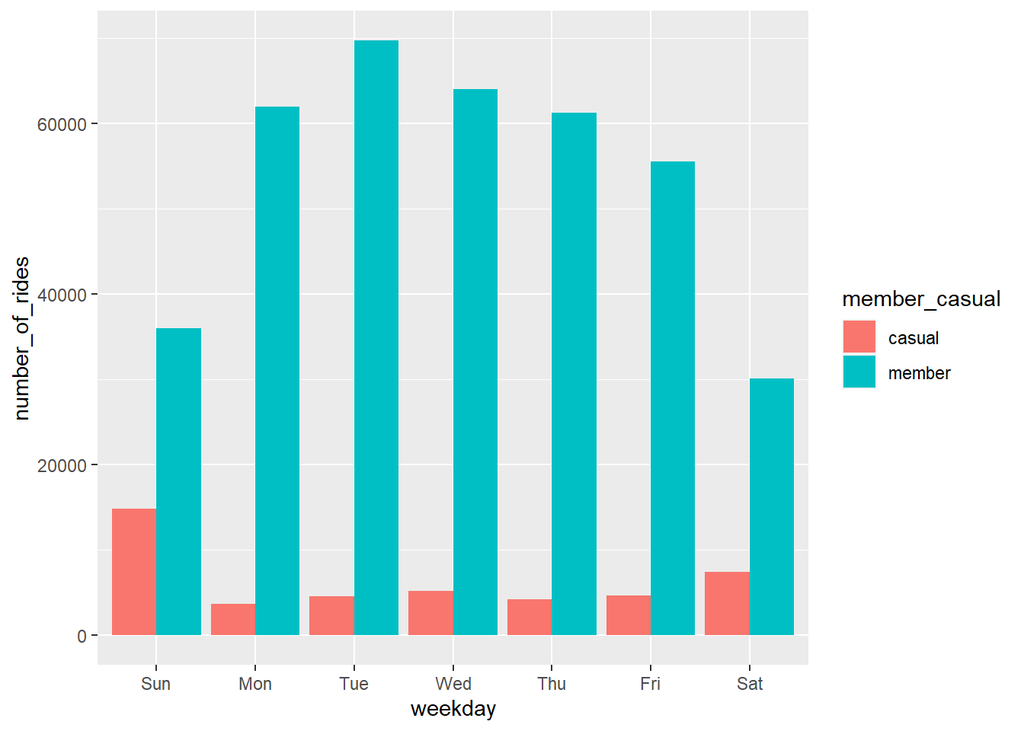

```r
q1_2020_v2 %>%
  mutate(weekday = wday(started_at, label = TRUE)) %>%
  group_by(member_casual, weekday) %>%
  summarise(number_of_rides = n()
            ,average_duration = mean(ride_length)) %>%
  arrange(member_casual, weekday)  %>%
  ggplot(aes(x = weekday, y = number_of_rides, fill = member_casual)) +
  geom_col(position = "dodge")
```

## Visualize for the average duration by rider type for each day of the week

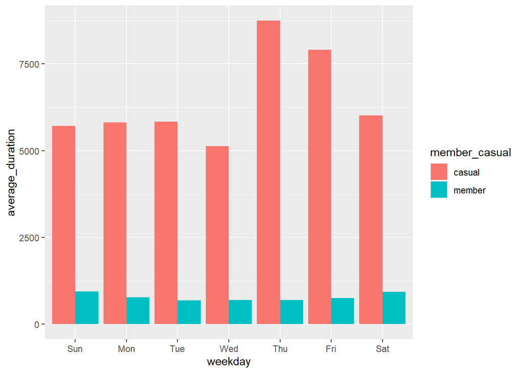

```r
q1_2020_v2 %>%
  mutate(weekday = wday(started_at, label = TRUE)) %>%
  group_by(member_casual, weekday) %>%
  summarise(number_of_rides = n()
            ,average_duration = mean(ride_length)) %>%
  arrange(member_casual, weekday)  %>%
  ggplot(aes(x = weekday, y = average_duration, fill = member_casual)) +
  geom_col(position = "dodge")
```